# Risk Factor Analysis

## Outcome Variable

**Outcome Variable:** pers_wast

## Predictor Variables

**Intervention Variable:** birthlen

**Adjustment Set:**

- arm
- sex
- W_mage
- meducyrs
- feducyrs
- vagbrth
- single
- brthmon
- W_parity
- delta_W_mage
- delta_meducyrs
- delta_feducyrs
- delta_vagbrth
- delta_single
- delta_brthmon
- delta_W_parity

## Stratifying Variables

The analysis was stratified on these variable(s):

- agecat
- studyid
- country

## Data Summary

| agecat | studyid | country | birthlen | pers_wast | n_cell | n |
| --- | --- | --- | --- | --- | --- | --- |
| 0-24 months | CMC-V-BCS-2002 | INDIA | >=50 cm | 0 | 16 | 106 |
| 0-24 months | CMC-V-BCS-2002 | INDIA | >=50 cm | 1 | 0 | 106 |
| 0-24 months | CMC-V-BCS-2002 | INDIA | <48 cm | 0 | 45 | 106 |
| 0-24 months | CMC-V-BCS-2002 | INDIA | <48 cm | 1 | 5 | 106 |
| 0-24 months | CMC-V-BCS-2002 | INDIA | [48-50) cm | 0 | 39 | 106 |
| 0-24 months | CMC-V-BCS-2002 | INDIA | [48-50) cm | 1 | 1 | 106 |
| 0-24 months | CMIN | BANGLADESH | >=50 cm | 0 | 0 | 12 |
| 0-24 months | CMIN | BANGLADESH | >=50 cm | 1 | 0 | 12 |
| 0-24 months | CMIN | BANGLADESH | <48 cm | 0 | 7 | 12 |
| 0-24 months | CMIN | BANGLADESH | <48 cm | 1 | 0 | 12 |
| 0-24 months | CMIN | BANGLADESH | [48-50) cm | 0 | 5 | 12 |
| 0-24 months | CMIN | BANGLADESH | [48-50) cm | 1 | 0 | 12 |
| 0-24 months | COHORTS | GUATEMALA | >=50 cm | 0 | 340 | 699 |
| 0-24 months | COHORTS | GUATEMALA | >=50 cm | 1 | 7 | 699 |
| 0-24 months | COHORTS | GUATEMALA | <48 cm | 0 | 136 | 699 |
| 0-24 months | COHORTS | GUATEMALA | <48 cm | 1 | 5 | 699 |
| 0-24 months | COHORTS | GUATEMALA | [48-50) cm | 0 | 206 | 699 |
| 0-24 months | COHORTS | GUATEMALA | [48-50) cm | 1 | 5 | 699 |
| 0-24 months | COHORTS | INDIA | >=50 cm | 0 | 1096 | 5267 |
| 0-24 months | COHORTS | INDIA | >=50 cm | 1 | 76 | 5267 |
| 0-24 months | COHORTS | INDIA | <48 cm | 0 | 1865 | 5267 |
| 0-24 months | COHORTS | INDIA | <48 cm | 1 | 253 | 5267 |
| 0-24 months | COHORTS | INDIA | [48-50) cm | 0 | 1799 | 5267 |
| 0-24 months | COHORTS | INDIA | [48-50) cm | 1 | 178 | 5267 |
| 0-24 months | COHORTS | PHILIPPINES | >=50 cm | 0 | 998 | 2804 |
| 0-24 months | COHORTS | PHILIPPINES | >=50 cm | 1 | 39 | 2804 |
| 0-24 months | COHORTS | PHILIPPINES | <48 cm | 0 | 653 | 2804 |
| 0-24 months | COHORTS | PHILIPPINES | <48 cm | 1 | 48 | 2804 |
| 0-24 months | COHORTS | PHILIPPINES | [48-50) cm | 0 | 1010 | 2804 |
| 0-24 months | COHORTS | PHILIPPINES | [48-50) cm | 1 | 56 | 2804 |

[output cut: 126 more lines]

The following strata were considered:

- agecat: 0-24 months, studyid: CMC-V-BCS-2002, country: INDIA
- agecat: 0-24 months, studyid: CMIN, country: BANGLADESH
- agecat: 0-24 months, studyid: COHORTS, country: GUATEMALA
- agecat: 0-24 months, studyid: COHORTS, country: INDIA
- agecat: 0-24 months, studyid: COHORTS, country: PHILIPPINES
- agecat: 0-24 months, studyid: CONTENT, country: PERU
- agecat: 0-24 months, studyid: EE, country: PAKISTAN
- agecat: 0-24 months, studyid: GMS-Nepal, country: NEPAL
- agecat: 0-24 months, studyid: IRC, country: INDIA
- agecat: 0-24 months, studyid: JiVitA-3, country: BANGLADESH
- agecat: 0-24 months, studyid: JiVitA-4, country: BANGLADESH
- agecat: 0-24 months, studyid: Keneba, country: GAMBIA
- agecat: 0-24 months, studyid: MAL-ED, country: BANGLADESH
- agecat: 0-24 months, studyid: MAL-ED, country: BRAZIL
- agecat: 0-24 months, studyid: MAL-ED, country: INDIA
- agecat: 0-24 months, studyid: MAL-ED, country: NEPAL
- agecat: 0-24 months, studyid: MAL-ED, country: PERU
- agecat: 0-24 months, studyid: MAL-ED, country: SOUTH AFRICA
- agecat: 0-24 months, studyid: MAL-ED, country: TANZANIA, UNITED REPUBLIC OF
- agecat: 0-24 months, studyid: NIH-Birth, country: BANGLADESH
- agecat: 0-24 months, studyid: NIH-Crypto, country: BANGLADESH
- agecat: 0-24 months, studyid: PROBIT, country: BELARUS
- agecat: 0-24 months, studyid: PROVIDE, country: BANGLADESH
- agecat: 0-24 months, studyid: ResPak, country: PAKISTAN
- agecat: 0-24 months, studyid: SAS-CompFeed, country: INDIA
- agecat: 0-24 months, studyid: ZVITAMBO, country: ZIMBABWE

### Dropped Strata

Some strata were dropped due to rare outcomes:

- agecat: 0-24 months, studyid: CMC-V-BCS-2002, country: INDIA
- agecat: 0-24 months, studyid: CMIN, country: BANGLADESH
- agecat: 0-24 months, studyid: CONTENT, country: PERU
- agecat: 0-24 months, studyid: EE, country: PAKISTAN
- agecat: 0-24 months, studyid: MAL-ED, country: BANGLADESH
- agecat: 0-24 months, studyid: MAL-ED, country: BRAZIL
- agecat: 0-24 months, studyid: MAL-ED, country: INDIA
- agecat: 0-24 months, studyid: MAL-ED, country: NEPAL
- agecat: 0-24 months, studyid: MAL-ED, country: PERU
- agecat: 0-24 months, studyid: MAL-ED, country: SOUTH AFRICA
- agecat: 0-24 months, studyid: MAL-ED, country: TANZANIA, UNITED REPUBLIC OF
- agecat: 0-24 months, studyid: NIH-Crypto, country: BANGLADESH
- agecat: 0-24 months, studyid: PROBIT, country: BELARUS
- agecat: 0-24 months, studyid: PROVIDE, country: BANGLADESH
- agecat: 0-24 months, studyid: ResPak, country: PAKISTAN

## Methods Detail

We're interested in the causal parameters $E[Y_a]$ for all values of $a \in \mathcal{A}$. These parameters represent the mean outcome if, possibly contrary to fact, we intervened to set all units to have $A=a$. Under the randomization and positivity assumptions, these are identified by the statistical parameters $\psi_a=E_W[E_{Y|A,W}(Y|A=a,W)]$. In addition, we're interested in the mean of $Y$, $E[Y]$ under no intervention (the observed mean). We will estimate these parameters by using SuperLearner to fit the relevant likelihood factors -- $E_{Y|A,W}(Y|A=a,W)$ and $p(A=a|W)$, and then updating our likelihood fit using a joint TMLE.

For unadjusted analyses ($W=\{\}$), initial likelihoods were estimated using Lrnr_glm to estimate the simple $E(Y|A)$ and Lrnr_mean to estimate $p(A)$. For adjusted analyses, a small library containing Lrnr_glmnet, Lrnr_xgboost, and Lrnr_mean was used.

Having estimated these parameters, we will then use the delta method to estimate relative risks and attributable risks relative to a prespecified baseline level of $A$.

# Results Detail

## Results Plots

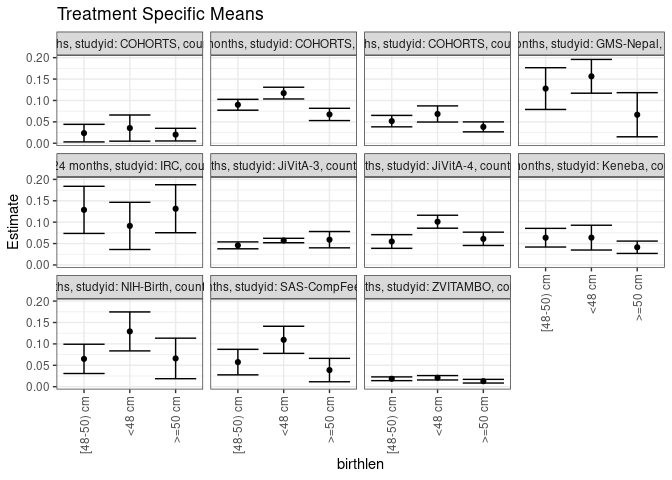

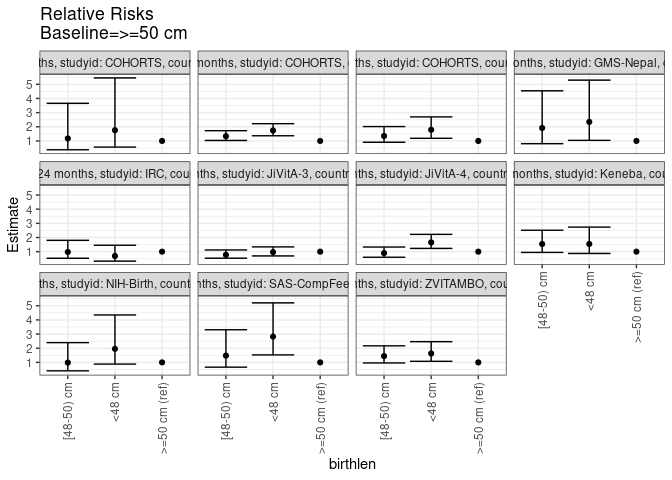

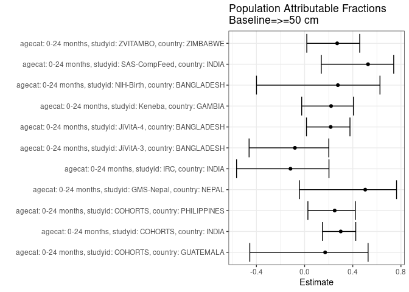

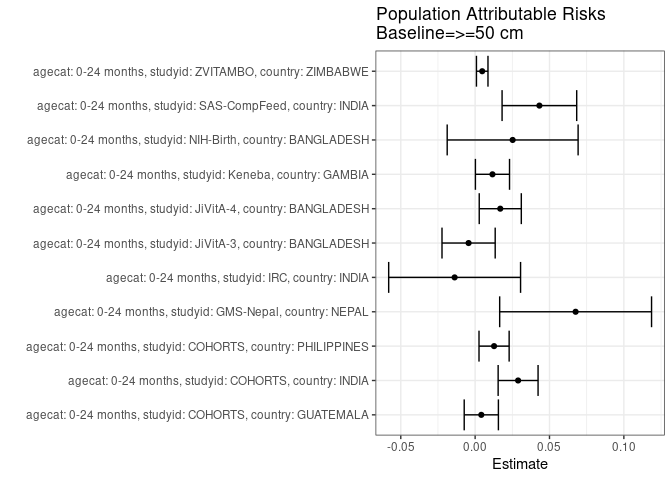

## Results Table

### Parameter: TSM

| agecat | studyid | country | intervention_level | baseline_level | estimate | ci_lower | ci_upper |
| --- | --- | --- | --- | --- | --- | --- | --- |
| 0-24 months | COHORTS | GUATEMALA | >=50 cm | NA | 0.0201729 | 0.0053698 | 0.0349760 |
| 0-24 months | COHORTS | GUATEMALA | <48 cm | NA | 0.0354610 | 0.0049129 | 0.0660091 |
| 0-24 months | COHORTS | GUATEMALA | [48-50) cm | NA | 0.0236967 | 0.0031589 | 0.0442345 |
| 0-24 months | COHORTS | INDIA | >=50 cm | NA | 0.0673671 | 0.0530017 | 0.0817326 |
| 0-24 months | COHORTS | INDIA | <48 cm | NA | 0.1172189 | 0.1034747 | 0.1309631 |
| 0-24 months | COHORTS | INDIA | [48-50) cm | NA | 0.0899393 | 0.0772324 | 0.1026461 |
| 0-24 months | COHORTS | PHILIPPINES | >=50 cm | NA | 0.0382617 | 0.0265924 | 0.0499311 |
| 0-24 months | COHORTS | PHILIPPINES | <48 cm | NA | 0.0684655 | 0.0496028 | 0.0873282 |
| 0-24 months | COHORTS | PHILIPPINES | [48-50) cm | NA | 0.0517523 | 0.0384022 | 0.0651024 |
| 0-24 months | GMS-Nepal | NEPAL | >=50 cm | NA | 0.0666667 | 0.0150887 | 0.1182446 |
| 0-24 months | GMS-Nepal | NEPAL | <48 cm | NA | 0.1564417 | 0.1169744 | 0.1959091 |
| 0-24 months | GMS-Nepal | NEPAL | [48-50) cm | NA | 0.1277778 | 0.0789668 | 0.1765888 |
| 0-24 months | IRC | INDIA | >=50 cm | NA | 0.1314390 | 0.0753560 | 0.1875219 |
| 0-24 months | IRC | INDIA | <48 cm | NA | 0.0913287 | 0.0361712 | 0.1464862 |
| 0-24 months | IRC | INDIA | [48-50) cm | NA | 0.1287881 | 0.0736772 | 0.1838990 |
| 0-24 months | JiVitA-3 | BANGLADESH | >=50 cm | NA | 0.0590850 | 0.0400168 | 0.0781533 |
| 0-24 months | JiVitA-3 | BANGLADESH | <48 cm | NA | 0.0571422 | 0.0519991 | 0.0622853 |
| 0-24 months | JiVitA-3 | BANGLADESH | [48-50) cm | NA | 0.0458931 | 0.0378097 | 0.0539764 |
| 0-24 months | JiVitA-4 | BANGLADESH | >=50 cm | NA | 0.0611021 | 0.0455829 | 0.0766214 |
| 0-24 months | JiVitA-4 | BANGLADESH | <48 cm | NA | 0.1010718 | 0.0859492 | 0.1161944 |
| 0-24 months | JiVitA-4 | BANGLADESH | [48-50) cm | NA | 0.0548596 | 0.0388625 | 0.0708566 |
| 0-24 months | Keneba | GAMBIA | >=50 cm | NA | 0.0413627 | 0.0269293 | 0.0557960 |
| 0-24 months | Keneba | GAMBIA | <48 cm | NA | 0.0638847 | 0.0349385 | 0.0928310 |
| 0-24 months | Keneba | GAMBIA | [48-50) cm | NA | 0.0637511 | 0.0419314 | 0.0855708 |
| 0-24 months | NIH-Birth | BANGLADESH | >=50 cm | NA | 0.0660377 | 0.0187141 | 0.1133614 |
| 0-24 months | NIH-Birth | BANGLADESH | <48 cm | NA | 0.1291866 | 0.0836702 | 0.1747030 |
| 0-24 months | NIH-Birth | BANGLADESH | [48-50) cm | NA | 0.0650000 | 0.0308007 | 0.0991993 |
| 0-24 months | SAS-CompFeed | INDIA | >=50 cm | NA | 0.0388350 | 0.0114714 | 0.0661985 |
| 0-24 months | SAS-CompFeed | INDIA | <48 cm | NA | 0.1095506 | 0.0778598 | 0.1412413 |
| 0-24 months | SAS-CompFeed | INDIA | [48-50) cm | NA | 0.0574713 | 0.0276190 | 0.0873235 |
| 0-24 months | ZVITAMBO | ZIMBABWE | >=50 cm | NA | 0.0128389 | 0.0085693 | 0.0171086 |
| 0-24 months | ZVITAMBO | ZIMBABWE | <48 cm | NA | 0.0209019 | 0.0157508 | 0.0260531 |
| 0-24 months | ZVITAMBO | ZIMBABWE | [48-50) cm | NA | 0.0185141 | 0.0141394 | 0.0228887 |

### Parameter: E(Y)

| agecat | studyid | country | intervention_level | baseline_level | estimate | ci_lower | ci_upper |
| --- | --- | --- | --- | --- | --- | --- | --- |
| 0-24 months | COHORTS | GUATEMALA | NA | NA | 0.0243205 | 0.0128927 | 0.0357482 |
| 0-24 months | COHORTS | INDIA | NA | NA | 0.0962597 | 0.0882935 | 0.1042259 |
| 0-24 months | COHORTS | PHILIPPINES | NA | NA | 0.0509986 | 0.0428544 | 0.0591428 |
| 0-24 months | GMS-Nepal | NEPAL | NA | NA | 0.1342282 | 0.1068369 | 0.1616195 |
| 0-24 months | IRC | INDIA | NA | NA | 0.1176471 | 0.0856708 | 0.1496233 |
| 0-24 months | JiVitA-3 | BANGLADESH | NA | NA | 0.0546893 | 0.0503788 | 0.0589997 |
| 0-24 months | JiVitA-4 | BANGLADESH | NA | NA | 0.0780045 | 0.0689447 | 0.0870643 |
| 0-24 months | Keneba | GAMBIA | NA | NA | 0.0530152 | 0.0417064 | 0.0643241 |
| 0-24 months | NIH-Birth | BANGLADESH | NA | NA | 0.0912621 | 0.0663660 | 0.1161582 |
| 0-24 months | SAS-CompFeed | INDIA | NA | NA | 0.0820399 | 0.0573937 | 0.1066861 |
| 0-24 months | ZVITAMBO | ZIMBABWE | NA | NA | 0.0175959 | 0.0149427 | 0.0202492 |

### Parameter: RR

| agecat | studyid | country | intervention_level | baseline_level | estimate | ci_lower | ci_upper |
| --- | --- | --- | --- | --- | --- | --- | --- |
| 0-24 months | COHORTS | GUATEMALA | >=50 cm | >=50 cm | 1.0000000 | 1.0000000 | 1.000000 |
| 0-24 months | COHORTS | GUATEMALA | <48 cm | >=50 cm | 1.7578521 | 0.5669193 | 5.450589 |
| 0-24 months | COHORTS | GUATEMALA | [48-50) cm | >=50 cm | 1.1746784 | 0.3773324 | 3.656907 |
| 0-24 months | COHORTS | INDIA | >=50 cm | >=50 cm | 1.0000000 | 1.0000000 | 1.000000 |
| 0-24 months | COHORTS | INDIA | <48 cm | >=50 cm | 1.7400018 | 1.3645921 | 2.218690 |
| 0-24 months | COHORTS | INDIA | [48-50) cm | >=50 cm | 1.3350617 | 1.0341800 | 1.723481 |
| 0-24 months | COHORTS | PHILIPPINES | >=50 cm | >=50 cm | 1.0000000 | 1.0000000 | 1.000000 |
| 0-24 months | COHORTS | PHILIPPINES | <48 cm | >=50 cm | 1.7893992 | 1.1865986 | 2.698427 |
| 0-24 months | COHORTS | PHILIPPINES | [48-50) cm | >=50 cm | 1.3525860 | 0.9073421 | 2.016316 |
| 0-24 months | GMS-Nepal | NEPAL | >=50 cm | >=50 cm | 1.0000000 | 1.0000000 | 1.000000 |
| 0-24 months | GMS-Nepal | NEPAL | <48 cm | >=50 cm | 2.3466258 | 1.0399944 | 5.294887 |
| 0-24 months | GMS-Nepal | NEPAL | [48-50) cm | >=50 cm | 1.9166667 | 0.8087628 | 4.542260 |
| 0-24 months | IRC | INDIA | >=50 cm | >=50 cm | 1.0000000 | 1.0000000 | 1.000000 |
| 0-24 months | IRC | INDIA | <48 cm | >=50 cm | 0.6948373 | 0.3319431 | 1.454463 |
| 0-24 months | IRC | INDIA | [48-50) cm | >=50 cm | 0.9798322 | 0.5332664 | 1.800359 |
| 0-24 months | JiVitA-3 | BANGLADESH | >=50 cm | >=50 cm | 1.0000000 | 1.0000000 | 1.000000 |
| 0-24 months | JiVitA-3 | BANGLADESH | <48 cm | >=50 cm | 0.9671184 | 0.6990636 | 1.337958 |
| 0-24 months | JiVitA-3 | BANGLADESH | [48-50) cm | >=50 cm | 0.7767290 | 0.5389067 | 1.119503 |
| 0-24 months | JiVitA-4 | BANGLADESH | >=50 cm | >=50 cm | 1.0000000 | 1.0000000 | 1.000000 |
| 0-24 months | JiVitA-4 | BANGLADESH | <48 cm | >=50 cm | 1.6541456 | 1.2311352 | 2.222500 |
| 0-24 months | JiVitA-4 | BANGLADESH | [48-50) cm | >=50 cm | 0.8978341 | 0.6076038 | 1.326697 |
| 0-24 months | Keneba | GAMBIA | >=50 cm | >=50 cm | 1.0000000 | 1.0000000 | 1.000000 |
| 0-24 months | Keneba | GAMBIA | <48 cm | >=50 cm | 1.5445025 | 0.8719807 | 2.735712 |
| 0-24 months | Keneba | GAMBIA | [48-50) cm | >=50 cm | 1.5412718 | 0.9454482 | 2.512585 |
| 0-24 months | NIH-Birth | BANGLADESH | >=50 cm | >=50 cm | 1.0000000 | 1.0000000 | 1.000000 |
| 0-24 months | NIH-Birth | BANGLADESH | <48 cm | >=50 cm | 1.9562543 | 0.8802817 | 4.347393 |
| 0-24 months | NIH-Birth | BANGLADESH | [48-50) cm | >=50 cm | 0.9842857 | 0.4045972 | 2.394525 |
| 0-24 months | SAS-CompFeed | INDIA | >=50 cm | >=50 cm | 1.0000000 | 1.0000000 | 1.000000 |
| 0-24 months | SAS-CompFeed | INDIA | <48 cm | >=50 cm | 2.8209270 | 1.5294183 | 5.203043 |
| 0-24 months | SAS-CompFeed | INDIA | [48-50) cm | >=50 cm | 1.4798851 | 0.6628767 | 3.303872 |
| 0-24 months | ZVITAMBO | ZIMBABWE | >=50 cm | >=50 cm | 1.0000000 | 1.0000000 | 1.000000 |
| 0-24 months | ZVITAMBO | ZIMBABWE | <48 cm | >=50 cm | 1.6280091 | 1.0761819 | 2.462793 |
| 0-24 months | ZVITAMBO | ZIMBABWE | [48-50) cm | >=50 cm | 1.4420241 | 0.9589338 | 2.168485 |

### Parameter: PAR

| agecat | studyid | country | intervention_level | baseline_level | estimate | ci_lower | ci_upper |
| --- | --- | --- | --- | --- | --- | --- | --- |
| 0-24 months | COHORTS | GUATEMALA | >=50 cm | NA | 0.0041475 | -0.0073486 | 0.0156437 |
| 0-24 months | COHORTS | INDIA | >=50 cm | NA | 0.0288926 | 0.0154693 | 0.0423159 |
| 0-24 months | COHORTS | PHILIPPINES | >=50 cm | NA | 0.0127368 | 0.0026056 | 0.0228681 |
| 0-24 months | GMS-Nepal | NEPAL | >=50 cm | NA | 0.0675615 | 0.0165015 | 0.1186216 |
| 0-24 months | IRC | INDIA | >=50 cm | NA | -0.0137919 | -0.0581331 | 0.0305493 |
| 0-24 months | JiVitA-3 | BANGLADESH | >=50 cm | NA | -0.0043958 | -0.0222791 | 0.0134875 |
| 0-24 months | JiVitA-4 | BANGLADESH | >=50 cm | NA | 0.0169024 | 0.0027598 | 0.0310450 |
| 0-24 months | Keneba | GAMBIA | >=50 cm | NA | 0.0116526 | 0.0001791 | 0.0231261 |
| 0-24 months | NIH-Birth | BANGLADESH | >=50 cm | NA | 0.0252244 | -0.0187919 | 0.0692407 |
| 0-24 months | SAS-CompFeed | INDIA | >=50 cm | NA | 0.0432050 | 0.0181178 | 0.0682921 |
| 0-24 months | ZVITAMBO | ZIMBABWE | >=50 cm | NA | 0.0047570 | 0.0008792 | 0.0086348 |

### Parameter: PAF

| agecat | studyid | country | intervention_level | baseline_level | estimate | ci_lower | ci_upper |
| --- | --- | --- | --- | --- | --- | --- | --- |
| 0-24 months | COHORTS | GUATEMALA | >=50 cm | NA | 0.1705374 | -0.4549860 | 0.5271375 |
| 0-24 months | COHORTS | INDIA | >=50 cm | NA | 0.3001526 | 0.1484406 | 0.4248359 |
| 0-24 months | COHORTS | PHILIPPINES | >=50 cm | NA | 0.2497487 | 0.0274559 | 0.4212324 |
| 0-24 months | GMS-Nepal | NEPAL | >=50 cm | NA | 0.5033333 | -0.0429660 | 0.7634843 |
| 0-24 months | IRC | INDIA | >=50 cm | NA | -0.1172313 | -0.5649207 | 0.2023841 |
| 0-24 months | JiVitA-3 | BANGLADESH | >=50 cm | NA | -0.0803772 | -0.4609359 | 0.2010500 |
| 0-24 months | JiVitA-4 | BANGLADESH | >=50 cm | NA | 0.2166850 | 0.0155991 | 0.3766946 |
| 0-24 months | Keneba | GAMBIA | >=50 cm | NA | 0.2197968 | -0.0240696 | 0.4055901 |
| 0-24 months | NIH-Birth | BANGLADESH | >=50 cm | NA | 0.2763950 | -0.3993750 | 0.6258300 |
| 0-24 months | SAS-CompFeed | INDIA | >=50 cm | NA | 0.5266334 | 0.1384809 | 0.7399060 |
| 0-24 months | ZVITAMBO | ZIMBABWE | >=50 cm | NA | 0.2703463 | 0.0183078 | 0.4576767 |